# Cleveland Browns Offense: Scouting Report

**Public data.** Built from nflverse (nflfastR play-by-play, NGS participation, FTN charting), mapped onto the PFF GamePBP layout. Run concepts, PFF success codes, yards after contact and receiver alignment are not in this source; see *What nflverse cannot cover* at the end.

**Sample:** 17 games (Sep 07, 2025 to Jan 04, 2026) · 987 offensive plays · Opponents: BLT, BUF, CHI, CIN, DET, GB, LV, MIA, MIN, NE, NYJ, PIT, SF, TEN  
**Source:** CLV_2025_nflverse_GamePBP.csv · Generated Nov 05, 2026 16:44 · Success = standard yardage definition · EPA = nflfastR model

62%Pass rate

54%Neutral early-down pass rate

-0.18EPA / play

38%Success rate

33%3rd-down conversion

8%Sack rate

7%Explosive play rate

## Key findings

### Tendencies

- Passes on 62% of all plays and 54% of neutral early-down plays (1st/2nd down, outside 2-minute drills).
- QB alignment is a strong run/pass key: under center they run 72% of the time (n=319); in shotgun they pass 80% (n=645).
- Pistol is a real part of the menu: 23 plays, 48% pass.
- Base personnel is 11 (44% of snaps, 71% pass). 6 groupings reach 10+ plays.
- Tell: 3rd Down + Extra Long (11+) -> pass 96% of the time (n=54, 95% lower bound 87%).
- Tell: 3rd Down + Medium (4-6) -> pass 94% of the time (n=53, 95% lower bound 85%).
- Tell: 3rd Down + Long (7-10) -> pass 93% of the time (n=70, 95% lower bound 84%).
- Tell: Shotgun + 3rd Down -> pass 88% of the time (n=200, 95% lower bound 82%).
- Run game is built on Middle and Right Guard: 47% of carries.
- Predictability: knowing personnel, alignment, down and distance lifts a defense’s run/pass guess from 62% to 76% (leave-one-out).

### Strengths

- Most efficient run gap: Right End, +0.02 EPA/carry, 4.5 YPC, 50% success (n=28).
- Primary target: J. Jeudy (#3) (WR), 20% target share, 48 catches for 580 yards, -0.31 EPA/target, 30 first downs.
- Most efficient receiver: C. Tillman (#19) (WR), +0.17 EPA/target on 39 targets, aDOT 11.9, 3.0 YAC/rec.
- Lead back Q. Judkins (#10): 59% of carries, 3.6 YPC, 42% success. Favorite gap: Middle.
- Most total value: C. Tillman (#19), 6.5 total EPA on 39 touches + targets (270 scrimmage yards).

### Vulnerabilities

- Play action: 22% of dropbacks, -0.28 EPA/play vs -0.23 without (n=138 vs 476).
- Deep shots (20+ air yards): 11% of targets, 28% complete, -0.22 EPA/target (n=53).
- Pressure breaks the passing game: -0.64 EPA/dropback when pressured vs +0.00 clean. Pressured on 38% of dropbacks; sack rate 8%.
- Least efficient run gap: Left Guard, -0.24 EPA/carry, stuffed (0 or fewer yards) on 22% (n=37).
- On 3rd and Extra Long (11+) they convert only 9% (n=54); they pass 96% of the time there. Overall 3rd-down conversion: 33%.
- Least productive personnel: 21, -0.32 EPA/play (n=14, 71% pass).
- High-volume, low-return target: J. Jeudy (#3) (WR), 20% of targets but -0.31 EPA/target and 47% catch rate.

**n** = the number of plays (or carries / targets) behind a number, i.e. the sample size. Findings are generated by fixed rules (see Methodology) and include sample sizes. Treat any rate built on fewer than 10 plays as anecdotal.

## 1. Personnel run/pass tendencies

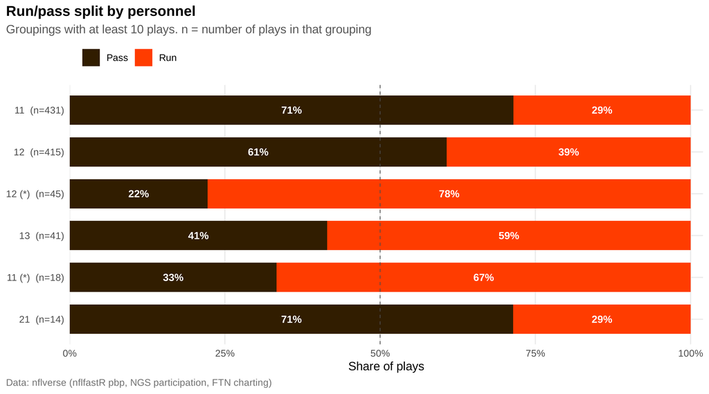

| Personnel | Plays | Snap % | Pass % | Pass % 95% CI | Run EPA | Pass EPA | Success |
| --- | --- | --- | --- | --- | --- | --- | --- |
| 11 | 431 | 44% | 71% | 67%-76% | -0.14 | -0.22 | 36% |
| 12 | 415 | 42% | 61% | 56%-65% | -0.07 | -0.25 | 40% |
| 12 (*) | 45 | 5% | 22% | 13%-36% | -0.07 | +0.22 | 40% |
| 13 | 41 | 4% | 41% | 28%-57% | -0.17 | -0.34 | 32% |
| 11 (*) | 18 | 2% | 33% | 16%-56% | +0.05 | -0.75 | 33% |
| 21 | 14 | 1% | 71% | 45%-88% | -0.07 | -0.42 | 50% |
| 02 | 7 | 1% | 100% | 65%-100% | n/a | -1.01 | 0% |
| 13 (*) | 7 | 1% | 0% | 0%-35% | +0.31 | n/a | 57% |
| 10 | 5 | 1% | 60% | 23%-88% | +0.41 | +0.94 | 60% |
| 01 | 1 | 0% | 0% | 0%-79% | -0.17 | n/a | 100% |
| 01 (*) | 1 | 0% | 100% | 21%-100% | n/a | -1.80 | 0% |
| 22 | 1 | 0% | 0% | 0%-79% | -0.36 | n/a | 0% |
| 22 (*) | 1 | 0% | 0% | 0%-79% | -1.77 | n/a | 0% |

## 2. Down-and-distance tendencies

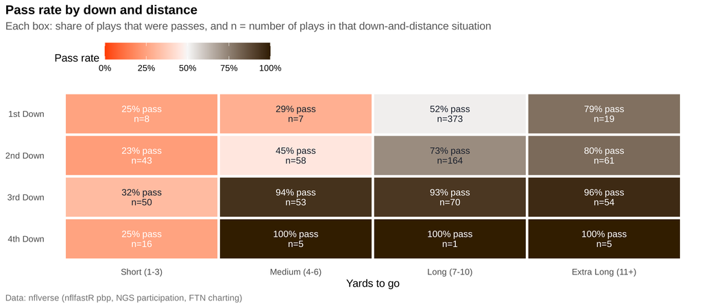

| Down | To go | Plays | Pass % | Run EPA | Pass EPA | Success |
| --- | --- | --- | --- | --- | --- | --- |
| 1st Down | Short (1-3) | 8 | 25% | +0.18 | -0.33 | 38% |
| 1st Down | Medium (4-6) | 7 | 29% | -0.11 | +0.51 | 71% |
| 1st Down | Long (7-10) | 373 | 52% | -0.14 | -0.17 | 41% |
| 1st Down | Extra Long (11+) | 19 | 79% | +0.09 | -0.15 | 37% |
| 2nd Down | Short (1-3) | 43 | 23% | +0.06 | -0.82 | 65% |
| 2nd Down | Medium (4-6) | 58 | 45% | -0.23 | -0.26 | 41% |
| 2nd Down | Long (7-10) | 164 | 73% | -0.20 | +0.02 | 34% |
| 2nd Down | Extra Long (11+) | 61 | 80% | -0.51 | -0.43 | 16% |
| 3rd Down | Short (1-3) | 50 | 32% | -0.06 | +0.02 | 62% |
| 3rd Down | Medium (4-6) | 53 | 94% | +0.96 | -0.23 | 40% |
| 3rd Down | Long (7-10) | 70 | 93% | -0.50 | -0.41 | 27% |
| 3rd Down | Extra Long (11+) | 54 | 96% | -0.48 | -0.19 | 9% |
| 4th Down | Short (1-3) | 16 | 25% | +1.19 | -0.15 | 75% |
| 4th Down | Medium (4-6) | 5 | 100% | n/a | -3.57 | 0% |
| 4th Down | Long (7-10) | 1 | 100% | n/a | -0.29 | 0% |
| 4th Down | Extra Long (11+) | 5 | 100% | n/a | -2.37 | 0% |

**By field position** (yards from the opponent’s end zone):

| Zone | Plays | Pass % | EPA/play | Success |
| --- | --- | --- | --- | --- |
| Goal to Go (1-10) | 54 | 41% | +0.14 | 43% |
| Red Zone (11-20) | 63 | 62% | -0.23 | 30% |
| Plus Territory (21-50) | 270 | 67% | -0.14 | 34% |
| Own Territory (51-80) | 511 | 62% | -0.22 | 41% |
| Backed Up (81-99) | 89 | 58% | -0.26 | 31% |

## 3. QB alignment tendencies

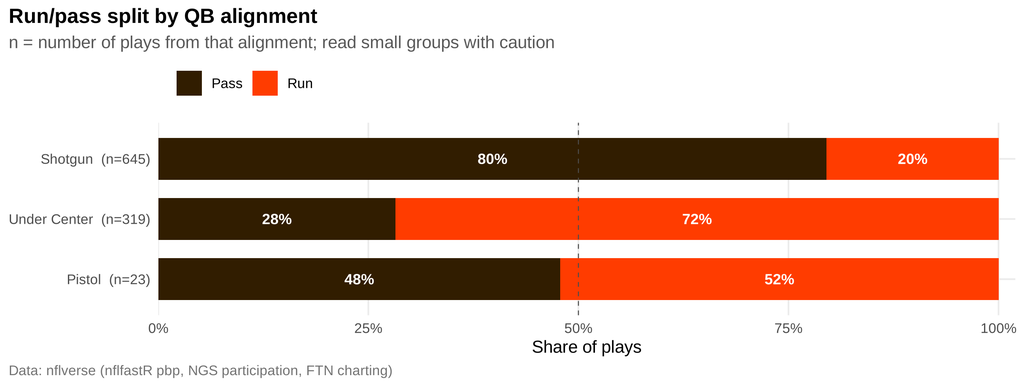

| Alignment | Plays | Snap % | Pass % | Run EPA | Pass EPA | Run YPC | Pass Y/P |
| --- | --- | --- | --- | --- | --- | --- | --- |
| Under Center | 319 | 32% | 28% | -0.09 | -0.27 | 3.6 | 4.4 |
| Shotgun | 645 | 65% | 80% | -0.09 | -0.23 | 3.4 | 5.0 |
| Pistol | 23 | 2% | 48% | -0.14 | -0.32 | 3.8 | 3.3 |

**Alignment by personnel** (groupings with enough plays):

| Personnel | Alignment | Plays | Pass % | EPA/play |
| --- | --- | --- | --- | --- |
| 02 | Shotgun | 7 | 100% | -1.01 |
| 10 | Shotgun | 5 | 60% | +0.72 |
| 11 | Under Center | 82 | 33% | -0.07 |
| 11 | Shotgun | 344 | 81% | -0.23 |
| 11 | Pistol | 5 | 40% | +0.05 |
| 11 (*) | Under Center | 15 | 33% | -0.18 |
| 12 | Under Center | 149 | 28% | -0.18 |
| 12 | Shotgun | 251 | 81% | -0.16 |
| 12 | Pistol | 15 | 47% | -0.43 |
| 12 (*) | Under Center | 42 | 24% | -0.05 |
| 13 | Under Center | 27 | 19% | -0.19 |
| 13 | Shotgun | 14 | 86% | -0.32 |
| 13 (*) | Shotgun | 6 | 0% | +0.43 |
| 21 | Shotgun | 10 | 80% | -0.76 |

## 4. Run gap and direction: frequency and effectiveness

nflverse does not chart blocking schemes, so runs are grouped by the gap and side the play-by-play records (end / tackle / guard / middle). This answers *where* they run, not *which concept*.

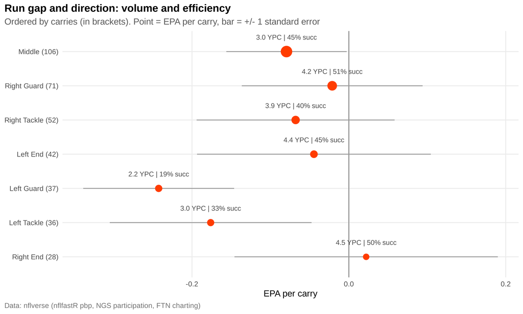

| Concept | Carries | Share | YPC | Median | Success | EPA/carry | Stuff % | Explosive % | Under center % | Top personnel |
| --- | --- | --- | --- | --- | --- | --- | --- | --- | --- | --- |
| Middle | 106 | 28% | 3.0 | 2.0 | 45% | -0.08 | 22% | 6% | 53% | 12 |
| Right Guard | 71 | 19% | 4.2 | 3.0 | 51% | -0.02 | 21% | 8% | 55% | 12 |
| Right Tackle | 52 | 14% | 3.9 | 3.0 | 40% | -0.07 | 17% | 8% | 75% | 12 |
| Left End | 42 | 11% | 4.4 | 3.0 | 45% | -0.04 | 26% | 17% | 76% | 12 |
| Left Guard | 37 | 10% | 2.2 | 2.0 | 19% | -0.24 | 22% | 3% | 35% | 12 |
| Left Tackle | 36 | 10% | 3.0 | 2.5 | 33% | -0.18 | 28% | 6% | 83% | 11 |
| Right End | 28 | 8% | 4.5 | 2.5 | 50% | +0.02 | 14% | 14% | 68% | 12 |

1 carry with no charted run gap is left out of this table.

## 5. Third-down behavior and key targets

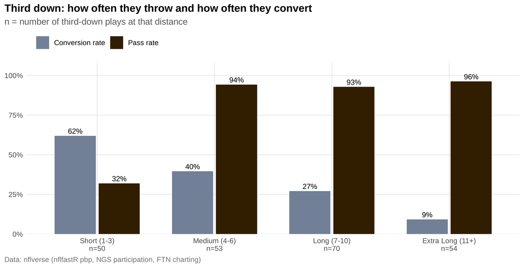

| To go | Plays | Pass % | Conv % | Conv 95% CI | EPA/play | Gun/Pistol % | Avg air yds | Sack % |
| --- | --- | --- | --- | --- | --- | --- | --- | --- |
| Short (1-3) | 50 | 32% | 62% | 48%-74% | -0.03 | 56% | 9.4 | 0% |
| Medium (4-6) | 53 | 94% | 40% | 28%-53% | -0.16 | 98% | 7.6 | 8% |
| Long (7-10) | 70 | 93% | 27% | 18%-39% | -0.42 | 100% | 9.5 | 15% |
| Extra Long (11+) | 54 | 96% | 9% | 4%-20% | -0.20 | 96% | 8.9 | 10% |

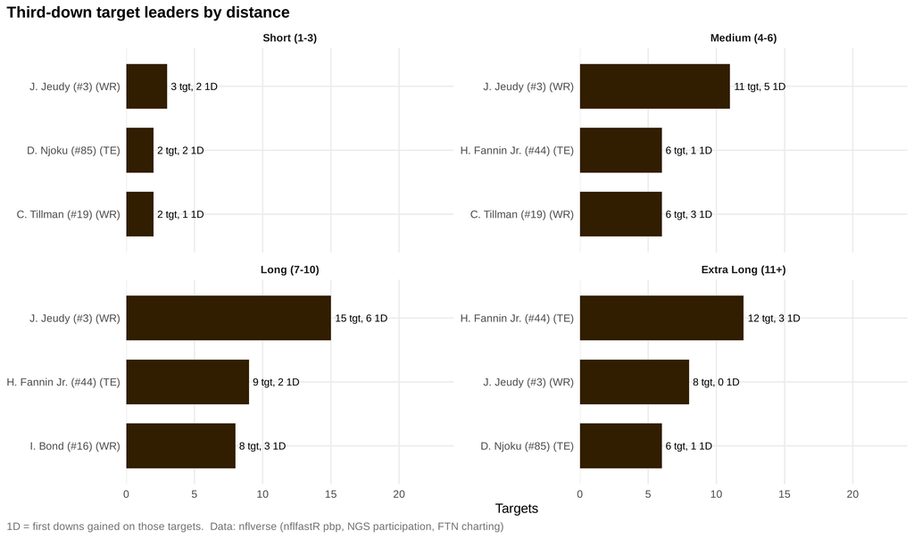

All third downs

| Player | Pos | Targets | Share | Rec | Yds | 1st downs | EPA/tgt | aDOT |
| --- | --- | --- | --- | --- | --- | --- | --- | --- |
| J. Jeudy (#3) | WR | 37 | 26% | 17 | 186 | 13 | -0.30 | 11.6 |
| H. Fannin Jr. (#44) | TE | 28 | 20% | 16 | 171 | 7 | -0.12 | 6.5 |
| I. Bond (#16) | WR | 19 | 13% | 8 | 154 | 5 | -0.17 | 19.1 |
| C. Tillman (#19) | WR | 14 | 10% | 8 | 109 | 6 | +0.15 | 12.1 |
| D. Njoku (#85) | TE | 14 | 10% | 9 | 90 | 4 | -0.77 | 6.0 |
| J. Ford (#34) | HB | 9 | 6% | 7 | 53 | 3 | +0.04 | -2.2 |
| D. Sampson (#22) | HB | 5 | 3% | 4 | 110 | 4 | +1.86 | -1.0 |
| G. Larvadain (#84) | WR | 5 | 3% | 3 | 35 | 1 | +0.18 | 10.6 |

## 6. Most effective players and how they produce

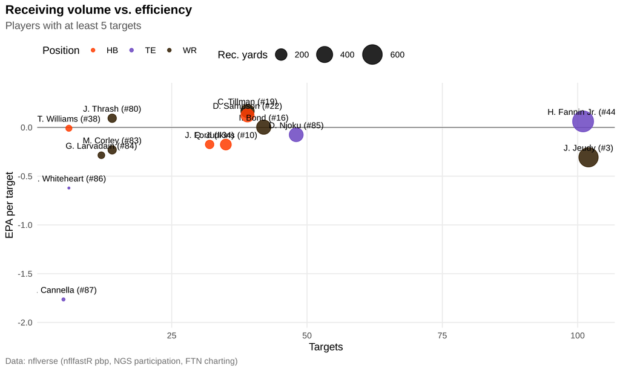

| Player | Pos | Tgt | Share | Rec | Yds | Catch % | Y/Tgt | aDOT | YAC/Rec | EPA/Tgt | 1D | Top route |
| --- | --- | --- | --- | --- | --- | --- | --- | --- | --- | --- | --- | --- |
| J. Jeudy (#3) | WR | 102 | 20% | 48 | 580 | 47% | 5.7 | 11.9 | 3.5 | -0.31 | 30 | IN/DIG |
| H. Fannin Jr. (#44) | TE | 101 | 20% | 68 | 690 | 67% | 6.8 | 5.9 | 5.0 | +0.06 | 30 | HITCH/CURL |
| D. Njoku (#85) | TE | 48 | 10% | 33 | 293 | 69% | 6.1 | 5.3 | 4.8 | -0.08 | 11 | HITCH/CURL |
| I. Bond (#16) | WR | 42 | 8% | 17 | 311 | 40% | 7.4 | 17.7 | 2.7 | +0.00 | 10 | GO |
| C. Tillman (#19) | WR | 39 | 8% | 21 | 270 | 54% | 6.9 | 11.9 | 3.0 | +0.17 | 13 | IN/DIG |
| D. Sampson (#22) | HB | 39 | 8% | 32 | 263 | 82% | 6.7 | -1.8 | 9.9 | +0.12 | 7 | SWING |
| Q. Judkins (#10) | HB | 35 | 7% | 25 | 175 | 71% | 5.0 | -0.3 | 7.8 | -0.18 | 7 | SCREEN |
| J. Ford (#34) | HB | 32 | 6% | 26 | 103 | 81% | 3.2 | -1.5 | 5.9 | -0.17 | 4 | SWING |
| J. Thrash (#80) | WR | 14 | 3% | 9 | 102 | 64% | 7.3 | 7.1 | 4.1 | +0.09 | 4 | QUICK OUT |
| M. Corley (#83) | WR | 14 | 3% | 11 | 100 | 79% | 7.1 | -0.5 | 6.2 | -0.23 | 5 | SCREEN |
| G. Larvadain (#84) | WR | 12 | 2% | 6 | 63 | 50% | 5.2 | 9.8 | 3.8 | -0.29 | 3 | IN/DIG |
| B. Whiteheart (#86) | TE | 6 | 1% | 2 | 4 | 33% | 0.7 | 7.2 | 0.5 | -0.62 | 0 | HITCH/CURL |

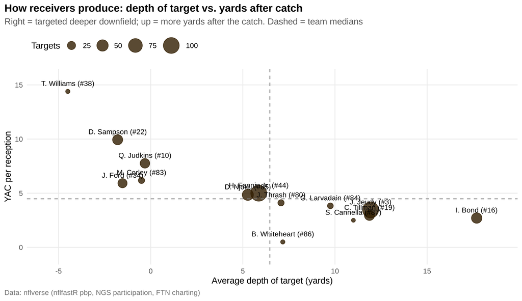

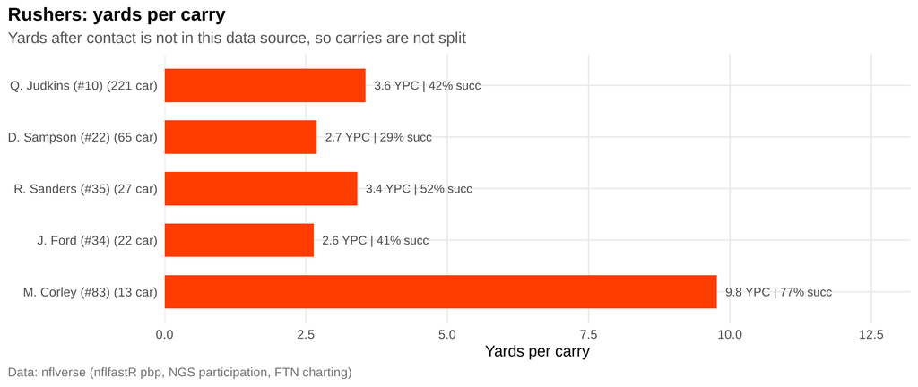

| Player | Carries | Share | Yds | YPC | Success | EPA/car | YBC | YACo | Explosive % | Stuff % | Top concept |
| --- | --- | --- | --- | --- | --- | --- | --- | --- | --- | --- | --- |
| Q. Judkins (#10) | 221 | 59% | 786 | 3.6 | 42% | -0.11 | n/a | n/a | 8% | 21% | Middle |
| D. Sampson (#22) | 65 | 17% | 175 | 2.7 | 29% | -0.26 | n/a | n/a | 5% | 28% | Right Tackle |
| R. Sanders (#35) | 27 | 7% | 92 | 3.4 | 52% | +0.03 | n/a | n/a | 4% | 22% | Middle |
| J. Ford (#34) | 22 | 6% | 58 | 2.6 | 41% | -0.18 | n/a | n/a | 9% | 18% | Middle |
| M. Corley (#83) | 13 | 3% | 127 | 9.8 | 77% | +0.56 | n/a | n/a | 46% | 8% | Left End |
| H. Fannin Jr. (#44) | 7 | 2% | 13 | 1.9 | 29% | -0.25 | n/a | n/a | 0% | 14% | Middle |
| T. Williams (#38) | 6 | 2% | 34 | 5.7 | 50% | +0.46 | n/a | n/a | 17% | 0% | Middle |
| I. Bond (#16) | 5 | 1% | 29 | 5.8 | 80% | +0.18 | n/a | n/a | 0% | 20% | Left End |

**Total offensive value** (rushing + receiving EPA; QB passing EPA is credited to targets):

| Player | Carries | Targets | Scrimmage yds | Rush EPA | Rec EPA | Total EPA | EPA/opp |
| --- | --- | --- | --- | --- | --- | --- | --- |
| C. Tillman (#19) | 0 | 39 | 270 | 0.0 | 6.5 | 6.5 | +0.17 |
| H. Fannin Jr. (#44) | 7 | 101 | 703 | -1.8 | 6.2 | 4.5 | +0.04 |
| M. Corley (#83) | 13 | 14 | 227 | 7.3 | -3.2 | 4.1 | +0.15 |
| T. Williams (#38) | 6 | 6 | 85 | 2.7 | -0.1 | 2.7 | +0.22 |
| R. Sanders (#35) | 27 | 4 | 113 | 0.9 | 1.2 | 2.1 | +0.07 |
| J. Thrash (#80) | 0 | 14 | 102 | 0.0 | 1.3 | 1.3 | +0.09 |
| I. Bond (#16) | 5 | 42 | 340 | 0.9 | 0.1 | 1.0 | +0.02 |
| S. Sanders (#12) | 1 | 0 | 4 | 0.9 | 0.0 | 0.9 | +0.92 |

## 7. Passing-game context

| Split | Value | Dropbacks | Share | EPA/play | Success | Y/P |
| --- | --- | --- | --- | --- | --- | --- |
| Play action | No | 476 | 78% | -0.23 | 34% | 4.8 |
| Play action | Yes | 138 | 22% | -0.28 | 38% | 5.0 |
| Screen | No | 560 | 91% | -0.26 | 35% | 4.8 |
| Screen | Yes | 54 | 9% | -0.05 | 37% | 5.6 |
| Pressure | Clean | 381 | 62% | +0.00 | 42% | 6.2 |
| Pressure | Pressured | 233 | 38% | -0.64 | 24% | 2.7 |

Targets by depth

| Depth | Targets | Share | Comp % | Y/Tgt | EPA/Tgt | INT % |
| --- | --- | --- | --- | --- | --- | --- |
| Behind LOS | 117 | 23% | 77% | 4.4 | -0.20 | 1% |
| Short (1-9) | 236 | 47% | 67% | 5.2 | -0.14 | 3% |
| Intermediate (10-19) | 97 | 19% | 48% | 8.3 | +0.23 | 3% |
| Deep (20+) | 53 | 11% | 28% | 9.6 | -0.22 | 11% |

Results by defensive coverage faced (5+ dropbacks)

| Coverage | Dropbacks | Share | EPA/play | Success |
| --- | --- | --- | --- | --- |
| COVER 3 | 163 | 27% | -0.33 | 29% |
| COVER 1 | 160 | 26% | -0.25 | 36% |
| COVER 2 | 139 | 23% | -0.23 | 39% |
| COVER 4 | 58 | 9% | -0.13 | 36% |
| COVER 2 MAN | 45 | 7% | +0.04 | 38% |
| COVER 6 | 25 | 4% | -0.91 | 36% |
| COVER 0 | 15 | 2% | +0.68 | 47% |
| COVER 9 | 8 | 1% | +0.09 | 38% |

## 8. Pre-snap tells and predictability

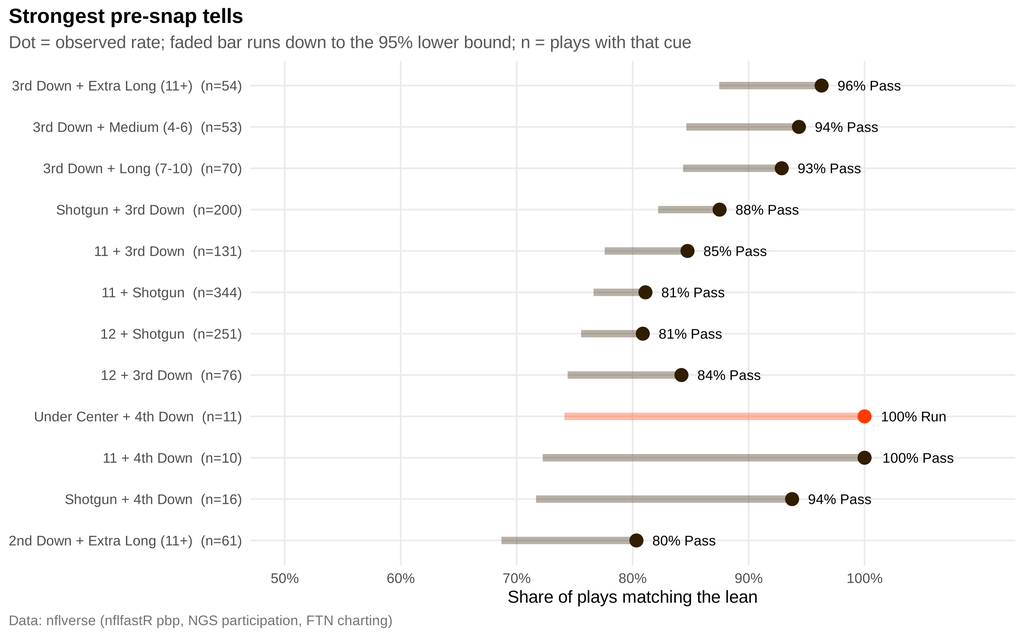

Always guessing the more common play type is right **62%** of the time. Using personnel, alignment, down and distance bucket (leave-one-out cell rates) is right **76%** of the time, a lift of **13%**.

## Methodology and data notes

How the sample was built

| Step | Plays |
| --- | --- |
| Offensive snaps in file | 1118 |
| Run or pass plays (drops penalties / no-plays) | 1030 |
| Downs 1-4 (drops PATs / 2-pt tries) | 1030 |
| Excluding garbage time | 992 |
| Excluding QB kneels and spikes | 987 |

### What nflverse cannot cover (or only approximates)

Column names below refer to the PFF GamePBP layout the nflverse data was mapped onto.

- **Pass play / dropback:** `pff_RUNPASS = "P"`, which includes sacks and QB scrambles. **Run:** `"R"`. Penalties and no-plays (`"X"`) are removed.
- **QB alignment:** Pistol if `pff_PISTOL` is set, otherwise Shotgun if `pff_SHOTGUN` is set, otherwise Under Center.
- **Success (standard):** gaining at least 40% of the distance on 1st down, 60% on 2nd, and 100% on 3rd/4th, or earning a first down. PFF success codes are not in nflverse, so only the standard rule is used.
- **First down:** `pff_FIRSTDOWNGAINED = 1` or yards gained ≥ distance.
- **EPA:** `pff_EXPECTEDPOINTSADDED` as provided. Passing EPA is attributed to the targeted receiver.
- **Target:** a pass play with a recorded receiver, excluding sacks and scrambles. **Receiving yards:** yards gained on completions.
- **Explosive:** runs of 10+ yards, passes of 20+ yards.
- **Field zone:** `ABSOLUTEYARDLINE` is yards to the opponent’s end zone (so 1–20 is the red zone).
- **Tell:** a pre-snap cue (personnel, alignment, down, distance, or combinations) with at least 10 plays where one play type reaches 80%. The 95% lower bound uses a Wilson interval.
- **Intervals:** rates show 95% Wilson intervals; run-concept EPA shows ±1 standard error. With samples this small, most differences between groups are not statistically distinguishable; the report shows n everywhere so readers can judge.
- **Garbage time** excluded: TRUE. **2-minute drills** excluded: FALSE. **Personnel “(*)“** marks a jumbo package (an extra offensive lineman replaces a skill player); merged into the base grouping: FALSE.

**Data checks:**

- Player names from CLV_2025_roster.csv (nflverse weekly rosters 2025)

Blank numeric cells (for example yards after catch on runs) are expected and listed for completeness.

Reproducibility: source file MD5 9a2ea3df40e7ac0f8cce012ed855b46d. Every table in this report is also saved as CSV and in one Excel workbook next to this file.